# Dual Personalities of CitiBike

## Travel Patterns of Bike commuters on weekdays & on weekends

```python
import numpy as np
import matplotlib.pyplot as plt
import folium
import pandas as pd
from IPython.display import display
from PIL import Image
```

[figure not shown]

```python
#citibike data Octobor, 2019
df= pd.read_csv("201910-citibike-tripdata.csv")
```

```python
df.head()
```

|  | tripduration | starttime | stoptime | start station id | start station name | start station latitude | start station longitude | end station id | end station name | end station latitude | end station longitude | bikeid | usertype | birth year | gender |
| --- | --- | --- | --- | --- | --- | --- | --- | --- | --- | --- | --- | --- | --- | --- | --- |
| 0 | 527 | 2019-10-01 00:00:05.6180 | 2019-10-01 00:08:52.9430 | 3746 | 6 Ave & Broome St | 40.724308 | -74.004730 | 223 | W 13 St & 7 Ave | 40.737815 | -73.999947 | 41750 | Subscriber | 1993 | 1 |
| 1 | 174 | 2019-10-01 00:00:15.8750 | 2019-10-01 00:03:10.1680 | 3301 | Columbus Ave & W 95 St | 40.791956 | -73.968087 | 3283 | W 89 St & Columbus Ave | 40.788221 | -73.970416 | 18264 | Subscriber | 1992 | 1 |
| 2 | 759 | 2019-10-01 00:00:19.8240 | 2019-10-01 00:12:59.7070 | 161 | LaGuardia Pl & W 3 St | 40.729170 | -73.998102 | 174 | E 25 St & 1 Ave | 40.738177 | -73.977387 | 25525 | Subscriber | 1995 | 1 |
| 3 | 615 | 2019-10-01 00:00:21.0680 | 2019-10-01 00:10:36.6790 | 254 | W 11 St & 6 Ave | 40.735324 | -73.998004 | 477 | W 41 St & 8 Ave | 40.756405 | -73.990026 | 30186 | Subscriber | 1992 | 1 |
| 4 | 761 | 2019-10-01 00:00:26.3800 | 2019-10-01 00:13:08.3130 | 161 | LaGuardia Pl & W 3 St | 40.729170 | -73.998102 | 174 | E 25 St & 1 Ave | 40.738177 | -73.977387 | 25597 | Subscriber | 1992 | 1 |

```python
df.dtypes
```

```
tripduration                 int64
starttime                   object
stoptime                    object
start station id             int64
start station name          object
start station latitude     float64
start station longitude    float64
end station id               int64
end station name            object
end station latitude       float64
end station longitude      float64
bikeid                       int64
usertype                    object
birth year                   int64
gender                       int64
dtype: object
```

```python
#focus on date and time
#convert [string] to [datetime]
from datetime import datetime
df['stoptime_dt']= pd.to_datetime(df['stoptime'])
df['starttime_dt']=pd.to_datetime(df['starttime'])
```

```python
df.head()
```

|  | tripduration | starttime | stoptime | start station id | start station name | start station latitude | start station longitude | end station id | end station name | end station latitude | end station longitude | bikeid | usertype | birth year | gender | stoptime_dt | starttime_dt |
| --- | --- | --- | --- | --- | --- | --- | --- | --- | --- | --- | --- | --- | --- | --- | --- | --- | --- |
| 0 | 527 | 2019-10-01 00:00:05.6180 | 2019-10-01 00:08:52.9430 | 3746 | 6 Ave & Broome St | 40.724308 | -74.004730 | 223 | W 13 St & 7 Ave | 40.737815 | -73.999947 | 41750 | Subscriber | 1993 | 1 | 2019-10-01 00:08:52.943 | 2019-10-01 00:00:05.618 |
| 1 | 174 | 2019-10-01 00:00:15.8750 | 2019-10-01 00:03:10.1680 | 3301 | Columbus Ave & W 95 St | 40.791956 | -73.968087 | 3283 | W 89 St & Columbus Ave | 40.788221 | -73.970416 | 18264 | Subscriber | 1992 | 1 | 2019-10-01 00:03:10.168 | 2019-10-01 00:00:15.875 |
| 2 | 759 | 2019-10-01 00:00:19.8240 | 2019-10-01 00:12:59.7070 | 161 | LaGuardia Pl & W 3 St | 40.729170 | -73.998102 | 174 | E 25 St & 1 Ave | 40.738177 | -73.977387 | 25525 | Subscriber | 1995 | 1 | 2019-10-01 00:12:59.707 | 2019-10-01 00:00:19.824 |
| 3 | 615 | 2019-10-01 00:00:21.0680 | 2019-10-01 00:10:36.6790 | 254 | W 11 St & 6 Ave | 40.735324 | -73.998004 | 477 | W 41 St & 8 Ave | 40.756405 | -73.990026 | 30186 | Subscriber | 1992 | 1 | 2019-10-01 00:10:36.679 | 2019-10-01 00:00:21.068 |
| 4 | 761 | 2019-10-01 00:00:26.3800 | 2019-10-01 00:13:08.3130 | 161 | LaGuardia Pl & W 3 St | 40.729170 | -73.998102 | 174 | E 25 St & 1 Ave | 40.738177 | -73.977387 | 25597 | Subscriber | 1992 | 1 | 2019-10-01 00:13:08.313 | 2019-10-01 00:00:26.380 |

### Question: On weekday, is rush-hour commute for the most part and probably from home to work? On weekend, is the riding pattern longer, more casual?

### Hypothesis: People always use Citi Bike to commute to work, and cycle to relax on weekends.

```python
# get the day of week
#df['weekday'] = df [].dt.weekday
# Datetime: from time (stoptime) to days of the week;
df['weekday'] = df['stoptime_dt'].dt.weekday
df.head()
```

|  | tripduration | starttime | stoptime | start station id | start station name | start station latitude | start station longitude | end station id | end station name | end station latitude | end station longitude | bikeid | usertype | birth year | gender | stoptime_dt | starttime_dt | weekday |
| --- | --- | --- | --- | --- | --- | --- | --- | --- | --- | --- | --- | --- | --- | --- | --- | --- | --- | --- |
| 0 | 527 | 2019-10-01 00:00:05.6180 | 2019-10-01 00:08:52.9430 | 3746 | 6 Ave & Broome St | 40.724308 | -74.004730 | 223 | W 13 St & 7 Ave | 40.737815 | -73.999947 | 41750 | Subscriber | 1993 | 1 | 2019-10-01 00:08:52.943 | 2019-10-01 00:00:05.618 | 1 |
| 1 | 174 | 2019-10-01 00:00:15.8750 | 2019-10-01 00:03:10.1680 | 3301 | Columbus Ave & W 95 St | 40.791956 | -73.968087 | 3283 | W 89 St & Columbus Ave | 40.788221 | -73.970416 | 18264 | Subscriber | 1992 | 1 | 2019-10-01 00:03:10.168 | 2019-10-01 00:00:15.875 | 1 |
| 2 | 759 | 2019-10-01 00:00:19.8240 | 2019-10-01 00:12:59.7070 | 161 | LaGuardia Pl & W 3 St | 40.729170 | -73.998102 | 174 | E 25 St & 1 Ave | 40.738177 | -73.977387 | 25525 | Subscriber | 1995 | 1 | 2019-10-01 00:12:59.707 | 2019-10-01 00:00:19.824 | 1 |
| 3 | 615 | 2019-10-01 00:00:21.0680 | 2019-10-01 00:10:36.6790 | 254 | W 11 St & 6 Ave | 40.735324 | -73.998004 | 477 | W 41 St & 8 Ave | 40.756405 | -73.990026 | 30186 | Subscriber | 1992 | 1 | 2019-10-01 00:10:36.679 | 2019-10-01 00:00:21.068 | 1 |
| 4 | 761 | 2019-10-01 00:00:26.3800 | 2019-10-01 00:13:08.3130 | 161 | LaGuardia Pl & W 3 St | 40.729170 | -73.998102 | 174 | E 25 St & 1 Ave | 40.738177 | -73.977387 | 25597 | Subscriber | 1992 | 1 | 2019-10-01 00:13:08.313 | 2019-10-01 00:00:26.380 | 1 |

```python
# Datetime Library: M = 0; T = 1; W = 2; TH = 3; F = 4; Sat = 5; SUN = 6
# convert [int64] to [string]
df['weekday'] = df['weekday'].apply(str)
df['weekday'].dtypes
```

```
dtype('O')
```

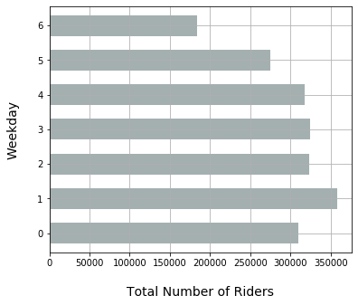

```python
# df.groupby().size; to calculate which day in a week is the busiest riding day
weekday = df.groupby('weekday').size()
p = weekday.plot(kind='barh', figsize=(6, 5), color='#a4afb0', width=0.6, grid = True)
p.set_xlabel("Total Number of Riders", labelpad=20, size=14)
p.set_ylabel("Weekday", labelpad=20,size=14)
```

More people using Citi Bike on weekdays than on weekends. Max: Tuesday; Min: Sunday I'll use Tuesday and Sunday as sample to prove my hypothesis.

### (1) Weekday Rush Hour: 08:00 - 10:00 am

```python
#get hh:mm from 'stoptime_dt'
df['hh'] = df['stoptime_dt'].dt.strftime('%H')
df.head()
```

|  | tripduration | starttime | stoptime | start station id | start station name | start station latitude | start station longitude | end station id | end station name | end station latitude | end station longitude | bikeid | usertype | birth year | gender | stoptime_dt | starttime_dt | weekday | hh |
| --- | --- | --- | --- | --- | --- | --- | --- | --- | --- | --- | --- | --- | --- | --- | --- | --- | --- | --- | --- |
| 0 | 527 | 2019-10-01 00:00:05.6180 | 2019-10-01 00:08:52.9430 | 3746 | 6 Ave & Broome St | 40.724308 | -74.004730 | 223 | W 13 St & 7 Ave | 40.737815 | -73.999947 | 41750 | Subscriber | 1993 | 1 | 2019-10-01 00:08:52.943 | 2019-10-01 00:00:05.618 | 1 | 00 |
| 1 | 174 | 2019-10-01 00:00:15.8750 | 2019-10-01 00:03:10.1680 | 3301 | Columbus Ave & W 95 St | 40.791956 | -73.968087 | 3283 | W 89 St & Columbus Ave | 40.788221 | -73.970416 | 18264 | Subscriber | 1992 | 1 | 2019-10-01 00:03:10.168 | 2019-10-01 00:00:15.875 | 1 | 00 |
| 2 | 759 | 2019-10-01 00:00:19.8240 | 2019-10-01 00:12:59.7070 | 161 | LaGuardia Pl & W 3 St | 40.729170 | -73.998102 | 174 | E 25 St & 1 Ave | 40.738177 | -73.977387 | 25525 | Subscriber | 1995 | 1 | 2019-10-01 00:12:59.707 | 2019-10-01 00:00:19.824 | 1 | 00 |
| 3 | 615 | 2019-10-01 00:00:21.0680 | 2019-10-01 00:10:36.6790 | 254 | W 11 St & 6 Ave | 40.735324 | -73.998004 | 477 | W 41 St & 8 Ave | 40.756405 | -73.990026 | 30186 | Subscriber | 1992 | 1 | 2019-10-01 00:10:36.679 | 2019-10-01 00:00:21.068 | 1 | 00 |
| 4 | 761 | 2019-10-01 00:00:26.3800 | 2019-10-01 00:13:08.3130 | 161 | LaGuardia Pl & W 3 St | 40.729170 | -73.998102 | 174 | E 25 St & 1 Ave | 40.738177 | -73.977387 | 25597 | Subscriber | 1992 | 1 | 2019-10-01 00:13:08.313 | 2019-10-01 00:00:26.380 | 1 | 00 |

```python
#select riders from 8-10 am on Tuesday(weekdays)
df[(df['weekday']== '1') & (df['hh'].isin(['08','09']))]
```

[output not shown]

70397 rows × 19 columns

```python
df1 = df[(df['weekday']== '1') & (df['hh'].isin(['08','09']))]
df1.head()
```

|  | tripduration | starttime | stoptime | start station id | start station name | start station latitude | start station longitude | end station id | end station name | end station latitude | end station longitude | bikeid | usertype | birth year | gender | stoptime_dt | starttime_dt | weekday | hh |
| --- | --- | --- | --- | --- | --- | --- | --- | --- | --- | --- | --- | --- | --- | --- | --- | --- | --- | --- | --- |
| 2729 | 7152 | 2019-10-01 06:30:35.5570 | 2019-10-01 08:29:47.7280 | 422 | W 59 St & 10 Ave | 40.770513 | -73.988038 | 520 | W 52 St & 5 Ave | 40.759923 | -73.976485 | 41551 | Subscriber | 1994 | 2 | 2019-10-01 08:29:47.728 | 2019-10-01 06:30:35.557 | 1 | 08 |
| 3489 | 5731 | 2019-10-01 06:47:47.9430 | 2019-10-01 08:23:19.5090 | 3287 | W 87 St & West End Ave | 40.789622 | -73.977570 | 3287 | W 87 St & West End Ave | 40.789622 | -73.977570 | 41904 | Subscriber | 1957 | 1 | 2019-10-01 08:23:19.509 | 2019-10-01 06:47:47.943 | 1 | 08 |
| 3589 | 8336 | 2019-10-01 06:49:20.5670 | 2019-10-01 09:08:17.3110 | 3687 | E 33 St & 1 Ave | 40.743227 | -73.974498 | 3687 | E 33 St & 1 Ave | 40.743227 | -73.974498 | 18049 | Customer | 1987 | 2 | 2019-10-01 09:08:17.311 | 2019-10-01 06:49:20.567 | 1 | 09 |
| 5047 | 2753 | 2019-10-01 07:14:59.8410 | 2019-10-01 08:00:52.9180 | 3047 | Halsey St & Tompkins Ave | 40.682369 | -73.944118 | 359 | E 47 St & Park Ave | 40.755103 | -73.974987 | 24911 | Subscriber | 1989 | 1 | 2019-10-01 08:00:52.918 | 2019-10-01 07:14:59.841 | 1 | 08 |
| 5134 | 2854 | 2019-10-01 07:16:10.2820 | 2019-10-01 08:03:44.5910 | 503 | E 20 St & Park Ave | 40.738274 | -73.987520 | 3567 | 11 St & 35 Ave | 40.762744 | -73.939114 | 38238 | Customer | 1969 | 0 | 2019-10-01 08:03:44.591 | 2019-10-01 07:16:10.282 | 1 | 08 |

```python
#Geodataframe
import geopandas
from shapely.geometry import Point
import warnings
warnings.simplefilter('ignore')
```

```python
#list(zip(df1['longitude'],df1['latitude']))
df1['endcoordinates'] = list(zip(df1['end station longitude'],df1['end station latitude']))
```

```python
# df1['coordinates'].apply(Point)
df1['endcoordinates'] = df1['endcoordinates'].apply(Point)
```

```python
gdf_Tuesday = geopandas.GeoDataFrame(df1, geometry='endcoordinates')
```

```python
gdf_Tuesday.head()
```

|  | tripduration | starttime | stoptime | start station id | start station name | start station latitude | start station longitude | end station id | end station name | end station latitude | end station longitude | bikeid | usertype | birth year | gender | stoptime_dt | starttime_dt | weekday | hh | endcoordinates |
| --- | --- | --- | --- | --- | --- | --- | --- | --- | --- | --- | --- | --- | --- | --- | --- | --- | --- | --- | --- | --- |
| 2729 | 7152 | 2019-10-01 06:30:35.5570 | 2019-10-01 08:29:47.7280 | 422 | W 59 St & 10 Ave | 40.770513 | -73.988038 | 520 | W 52 St & 5 Ave | 40.759923 | -73.976485 | 41551 | Subscriber | 1994 | 2 | 2019-10-01 08:29:47.728 | 2019-10-01 06:30:35.557 | 1 | 08 | POINT (-73.97649 40.75992) |
| 3489 | 5731 | 2019-10-01 06:47:47.9430 | 2019-10-01 08:23:19.5090 | 3287 | W 87 St & West End Ave | 40.789622 | -73.977570 | 3287 | W 87 St & West End Ave | 40.789622 | -73.977570 | 41904 | Subscriber | 1957 | 1 | 2019-10-01 08:23:19.509 | 2019-10-01 06:47:47.943 | 1 | 08 | POINT (-73.97757 40.78962) |
| 3589 | 8336 | 2019-10-01 06:49:20.5670 | 2019-10-01 09:08:17.3110 | 3687 | E 33 St & 1 Ave | 40.743227 | -73.974498 | 3687 | E 33 St & 1 Ave | 40.743227 | -73.974498 | 18049 | Customer | 1987 | 2 | 2019-10-01 09:08:17.311 | 2019-10-01 06:49:20.567 | 1 | 09 | POINT (-73.97450 40.74323) |
| 5047 | 2753 | 2019-10-01 07:14:59.8410 | 2019-10-01 08:00:52.9180 | 3047 | Halsey St & Tompkins Ave | 40.682369 | -73.944118 | 359 | E 47 St & Park Ave | 40.755103 | -73.974987 | 24911 | Subscriber | 1989 | 1 | 2019-10-01 08:00:52.918 | 2019-10-01 07:14:59.841 | 1 | 08 | POINT (-73.97499 40.75510) |
| 5134 | 2854 | 2019-10-01 07:16:10.2820 | 2019-10-01 08:03:44.5910 | 503 | E 20 St & Park Ave | 40.738274 | -73.987520 | 3567 | 11 St & 35 Ave | 40.762744 | -73.939114 | 38238 | Customer | 1969 | 0 | 2019-10-01 08:03:44.591 | 2019-10-01 07:16:10.282 | 1 | 08 | POINT (-73.93911 40.76274) |

```python
gdf_Tuesday_rushhour = gdf_Tuesday[[
    'tripduration',
    'end station id',
    'end station name',
    'stoptime_dt',
    'starttime_dt',
    'weekday',
    'hh',
    'endcoordinates',
    'usertype',
    'birth year']]
```

```python
gdf_Tuesday_rushhour.to_csv('gdf_Tuesday_rush_hour.csv')
```

```python
# arriving: end station
arriving = gdf_Tuesday.groupby(['end station latitude','end station longitude','end station name']).size()
arriving.head(10)
```

```
end station latitude  end station longitude  end station name
40.655400             -74.010628             39 St & 2 Ave - Citi Bike HQ at Industry City     7
40.657089             -74.008702             2 Ave & 36 St - Citi Bike HQ at Industry City    10
40.661063             -73.979453             West Drive & Prospect Park West                  27
40.662706             -73.956912             Sterling St & Bedford Ave                         3
40.663062             -73.953875             Rogers Ave & Sterling St                          5
40.663140             -73.960569             Franklin Ave & Empire Blvd                       14
40.663779             -73.983968             14 St & 7 Ave                                    10
40.665147             -73.976376             Prospect Park West & 8 St                        18
40.665816             -73.956934             Bedford Ave & Montgomery St                       1
40.666208             -73.981999             10 St & 7 Ave                                    18
dtype: int64
```

```python
# arriving: end station
# Which stations are the busiest stations in rush hours on weekdays?
arriving_sort = arriving.sort_values(ascending = False)
arriving_sort.head(5)
```

```
end station latitude  end station longitude  end station name
40.740343             -73.989551             Broadway & E 22 St       1025
40.755103             -73.974987             E 47 St & Park Ave        924
40.751873             -73.977706             Pershing Square North     793
40.717548             -74.013221             West St & Chambers St     722
40.740964             -73.986022             E 24 St & Park Ave S      711
dtype: int64
```

```python
# Top 5 busiest station at rush hour on Tuesday:
## Broadway & E 22 St
## E 47 St & Park Ave
## Pershing Square North
## West St & Chambers St
## E 24 St & Park Ave S
```

```python
for i in range(10):
    print(arriving_sort.keys()[i])
```

```
(40.740343200000005, -73.98955109, 'Broadway & E 22 St')
(40.75510267, -73.97498696, 'E 47 St & Park Ave')
(40.751872999999996, -73.97770600000001, 'Pershing Square North')
(40.71754834, -74.01322069, 'West St & Chambers St')
(40.74096374, -73.98602213, 'E 24 St & Park Ave S')
(40.75724567911726, -73.97805914282799, 'E 48 St & 5 Ave')
(40.764397100000004, -73.97371465, 'Grand Army Plaza & Central Park S')
(40.751396, -74.00522600000001, '11 Ave & W 27 St')
(40.75513557, -73.98658032, 'Broadway & W 41 St')
(40.72243797, -74.00566443, '6 Ave & Canal St')
```

```python
len(arriving_sort)
```

```
810
```

```python
# plot the arriving points on map(zoom Manhattan)
# m = folium.Map()
latitude = []
longitude = []
number = []
for i in range(len(arriving_sort)):
    lat = arriving_sort.keys()[i][0]
    long = arriving_sort.keys()[i][1]
    total = arriving_sort[i]
    latitude.append(lat)
    longitude.append(long)
    number.append(total)

m = folium.Map(location=[40.76727216, -73.99392888], tiles='cartodbpositron',zoom_start = 12)
for j in range(0,len(latitude)):
    labels = number[j]
    folium.CircleMarker(
        location = [latitude[j],longitude[j]],
        radius = number[j]/100,
        color = '#ce6dbd',
        fill_color='#ce6dbd',
        popup=labels).add_to(m)
```

```python
display(m)
```

[interactive chart not shown]

```python
#download the map
m.save('html_map_output_Tuesday_rushhour.html')
```

```python
riders_Tuesday = gdf_Tuesday.groupby(['birth year']).size()
riders_Tuesday.head(10)
```

```
birth year
1888    2
1889    3
1890    1
1893    8
1900    9
1901    3
1907    1
1911    3
1917    1
1921    2
dtype: int64
```

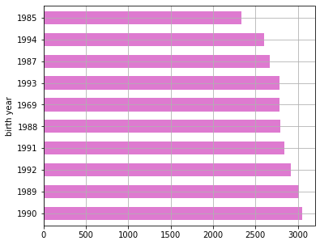

```python
riders_Tuesday_sort = riders_Tuesday.sort_values(ascending = False)
riders_Tuesday_sort.head(10).plot(
    kind='barh',
    figsize=(6, 5),
    color='#de7ad0',
    width=0.6,
    grid = True)
```

```python
# Who rides during rush hour on Tuesday?
# 1990; 1989; 1992;
# year-old: 29; 30; 27
```

```python
trip_T = gdf_Tuesday.groupby(['tripduration']).size()
trip_T.head(10)
```

```
tripduration
61     4
62     9
63     5
64     4
65    10
66    14
67     6
68     9
69    14
70     4
dtype: int64
```

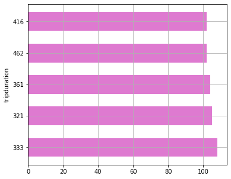

```python
trip_T_sort = trip_T.sort_values(ascending = False)
trip_T_sort.head(5).plot(
    kind='barh',
    figsize=(6, 5),
    color='#de7ad0',
    width=0.6,
    grid = True)
```

```python
# In this case, more ridings are around 5 minutes.
```